# DSC week 14 IP - Dimenstionality Reduction and Feature Selection

Wambui

29/01/2021

## CarreFour Kenya Sales increment strategies

### 1. Research Question

Carrefour Kenya and are currently undertaking a project that will inform the marketing department on the most relevant marketing strategies that will result in the highest number of sales (total price including tax).

### 2. Metric of Success

identifying the principal components that contribute to sales.

### 3. Understanding the context.

Sales transactional data has been acquired from the Carrefour Kenya stores in Kenya

### 4. Recording the Experimental Design

1. Data Loading
2. Data Cleaning and processing
3. Exploratory Data Analysis
4. PCA and Feature Selection
5. Recommendations and Conclusions

### 5. Data Relevance.

The provided data is relevant for this kind of study

### Data Preview

```r
#install.packages("caret")
#loading the library
library(data.table) # load package
library(tidyverse)
library("caret")
# Dataset Url = http://bit.ly/CarreFourDataset

# Importing our dataset
#
sales_data <- read.csv('http://bit.ly/CarreFourDataset')
```

# Check the Data

```r
head(sales_data,6)
```

```
##    Invoice.ID Branch Customer.type Gender           Product.line Unit.price
## 1 750-67-8428      A        Member Female      Health and beauty      74.69
## 2 226-31-3081      C        Normal Female Electronic accessories      15.28
## 3 631-41-3108      A        Normal   Male     Home and lifestyle      46.33
## 4 123-19-1176      A        Member   Male      Health and beauty      58.22
## 5 373-73-7910      A        Normal   Male      Sports and travel      86.31
## 6 699-14-3026      C        Normal   Male Electronic accessories      85.39
##   Quantity     Tax      Date  Time     Payment   cogs gross.margin.percentage
## 1        7 26.1415  1/5/2019 13:08     Ewallet 522.83                4.761905
## 2        5  3.8200  3/8/2019 10:29        Cash  76.40                4.761905
## 3        7 16.2155  3/3/2019 13:23 Credit card 324.31                4.761905
## 4        8 23.2880 1/27/2019 20:33     Ewallet 465.76                4.761905
## 5        7 30.2085  2/8/2019 10:37     Ewallet 604.17                4.761905
## 6        7 29.8865 3/25/2019 18:30     Ewallet 597.73                4.761905
##   gross.income Rating    Total
## 1      26.1415    9.1 548.9715
## 2       3.8200    9.6  80.2200
## 3      16.2155    7.4 340.5255
## 4      23.2880    8.4 489.0480
## 5      30.2085    5.3 634.3785
## 6      29.8865    4.1 627.6165
```

```r
tail(sales_data,6)
```

```
##       Invoice.ID Branch Customer.type Gender           Product.line Unit.price
## 995  652-49-6720      C        Member Female Electronic accessories      60.95
## 996  233-67-5758      C        Normal   Male      Health and beauty      40.35
## 997  303-96-2227      B        Normal Female     Home and lifestyle      97.38
## 998  727-02-1313      A        Member   Male     Food and beverages      31.84
## 999  347-56-2442      A        Normal   Male     Home and lifestyle      65.82
## 1000 849-09-3807      A        Member Female    Fashion accessories      88.34
##      Quantity     Tax      Date  Time Payment   cogs gross.margin.percentage
## 995         1  3.0475 2/18/2019 11:40 Ewallet  60.95                4.761905
## 996         1  2.0175 1/29/2019 13:46 Ewallet  40.35                4.761905
## 997        10 48.6900  3/2/2019 17:16 Ewallet 973.80                4.761905
## 998         1  1.5920  2/9/2019 13:22    Cash  31.84                4.761905
## 999         1  3.2910 2/22/2019 15:33    Cash  65.82                4.761905
## 1000        7 30.9190 2/18/2019 13:28    Cash 618.38                4.761905
##      gross.income Rating     Total
## 995        3.0475    5.9   63.9975
## 996        2.0175    6.2   42.3675
## 997       48.6900    4.4 1022.4900
## 998        1.5920    7.7   33.4320
## 999        3.2910    4.1   69.1110
## 1000      30.9190    6.6  649.2990
```

```r
colnames(sales_data)
```

```
##  [1] "Invoice.ID"              "Branch"
##  [3] "Customer.type"           "Gender"
##  [5] "Product.line"            "Unit.price"
##  [7] "Quantity"                "Tax"
##  [9] "Date"                    "Time"
## [11] "Payment"                 "cogs"
## [13] "gross.margin.percentage" "gross.income"
## [15] "Rating"                  "Total"
```

```r
dim(sales_data)
```

```
## [1] 1000   16
```

Observation: the tables has 1000 records and 16 columns.

```r
str(sales_data)
```

```
## 'data.frame':    1000 obs. of  16 variables:
##  $ Invoice.ID             : chr  "750-67-8428" "226-31-3081" "631-41-3108" "123-19-1176" ...
##  $ Branch                 : chr  "A" "C" "A" "A" ...
##  $ Customer.type          : chr  "Member" "Normal" "Normal" "Member" ...
##  $ Gender                 : chr  "Female" "Female" "Male" "Male" ...
##  $ Product.line           : chr  "Health and beauty" "Electronic accessories" "Home and lifestyle" "Health and beauty" ...
##  $ Unit.price             : num  74.7 15.3 46.3 58.2 86.3 ...
##  $ Quantity               : int  7 5 7 8 7 7 6 10 2 3 ...
##  $ Tax                    : num  26.14 3.82 16.22 23.29 30.21 ...
##  $ Date                   : chr  "1/5/2019" "3/8/2019" "3/3/2019" "1/27/2019" ...
##  $ Time                   : chr  "13:08" "10:29" "13:23" "20:33" ...
##  $ Payment                : chr  "Ewallet" "Cash" "Credit card" "Ewallet" ...
##  $ cogs                   : num  522.8 76.4 324.3 465.8 604.2 ...
##  $ gross.margin.percentage: num  4.76 4.76 4.76 4.76 4.76 ...
##  $ gross.income           : num  26.14 3.82 16.22 23.29 30.21 ...
##  $ Rating                 : num  9.1 9.6 7.4 8.4 5.3 4.1 5.8 8 7.2 5.9 ...
##  $ Total                  : num  549 80.2 340.5 489 634.4 ...
```

Observation: There are 8 numerical columns and 8 categorical columns.

### converting the data into a tibble for easy manupulation

```r
#For ease in analysis,we convert the data into a tibble
df_sales<-as_tibble(sales_data)
df_sales
```

```
## # A tibble: 1,000 x 16
##    Invoice.ID Branch Customer.type Gender Product.line Unit.price Quantity   Tax
##    <chr>      <chr>  <chr>         <chr>  <chr>             <dbl>    <int> <dbl>
##  1 750-67-84~ A      Member        Female Health and ~       74.7        7 26.1
##  2 226-31-30~ C      Normal        Female Electronic ~       15.3        5  3.82
##  3 631-41-31~ A      Normal        Male   Home and li~       46.3        7 16.2
##  4 123-19-11~ A      Member        Male   Health and ~       58.2        8 23.3
##  5 373-73-79~ A      Normal        Male   Sports and ~       86.3        7 30.2
##  6 699-14-30~ C      Normal        Male   Electronic ~       85.4        7 29.9
##  7 355-53-59~ A      Member        Female Electronic ~       68.8        6 20.7
##  8 315-22-56~ C      Normal        Female Home and li~       73.6       10 36.8
##  9 665-32-91~ A      Member        Female Health and ~       36.3        2  3.63
## 10 692-92-55~ B      Member        Female Food and be~       54.8        3  8.23
## # ... with 990 more rows, and 8 more variables: Date <chr>, Time <chr>,
## #   Payment <chr>, cogs <dbl>, gross.margin.percentage <dbl>,
## #   gross.income <dbl>, Rating <dbl>, Total <dbl>
```

```r
summary(df_sales)
```

```
##   Invoice.ID           Branch          Customer.type         Gender
##  Length:1000        Length:1000        Length:1000        Length:1000
##  Class :character   Class :character   Class :character   Class :character
##  Mode  :character   Mode  :character   Mode  :character   Mode  :character
##
##
##
##  Product.line         Unit.price       Quantity          Tax
##  Length:1000        Min.   :10.08   Min.   : 1.00   Min.   : 0.5085
##  Class :character   1st Qu.:32.88   1st Qu.: 3.00   1st Qu.: 5.9249
##  Mode  :character   Median :55.23   Median : 5.00   Median :12.0880
##                     Mean   :55.67   Mean   : 5.51   Mean   :15.3794
##                     3rd Qu.:77.94   3rd Qu.: 8.00   3rd Qu.:22.4453
##                     Max.   :99.96   Max.   :10.00   Max.   :49.6500
##      Date               Time             Payment               cogs
##  Length:1000        Length:1000        Length:1000        Min.   : 10.17
##  Class :character   Class :character   Class :character   1st Qu.:118.50
##  Mode  :character   Mode  :character   Mode  :character   Median :241.76
##                                                           Mean   :307.59
##                                                           3rd Qu.:448.90
##                                                           Max.   :993.00
##  gross.margin.percentage  gross.income         Rating           Total
##  Min.   :4.762           Min.   : 0.5085   Min.   : 4.000   Min.   :  10.68
##  1st Qu.:4.762           1st Qu.: 5.9249   1st Qu.: 5.500   1st Qu.: 124.42
##  Median :4.762           Median :12.0880   Median : 7.000   Median : 253.85
##  Mean   :4.762           Mean   :15.3794   Mean   : 6.973   Mean   : 322.97
##  3rd Qu.:4.762           3rd Qu.:22.4453   3rd Qu.: 8.500   3rd Qu.: 471.35
##  Max.   :4.762           Max.   :49.6500   Max.   :10.000   Max.   :1042.65
```

Observation: Statistical Summary of dataset

##Data Cleaning ## Checking for Null Values

```r
total_null <- sum(is.na(df_sales))
total_null
```

```
## [1] 0
```

Observation: No null values noted

## Duplicates

```r
duplicated_rows <- df_sales[duplicated(df_sales),]
nrow(duplicated_rows)
```

```
## [1] 0
```

# Checking for outliers using Boxplots

```r
df_sales_numeric<- df_sales %>% select_if(is.numeric)
df_sales_numeric
```

```
## # A tibble: 1,000 x 8
##    Unit.price Quantity   Tax  cogs gross.margin.perce~ gross.income Rating Total
##         <dbl>    <int> <dbl> <dbl>               <dbl>        <dbl>  <dbl> <dbl>
##  1       74.7        7 26.1  523.                 4.76        26.1     9.1 549.
##  2       15.3        5  3.82  76.4                4.76         3.82    9.6  80.2
##  3       46.3        7 16.2  324.                 4.76        16.2     7.4 341.
##  4       58.2        8 23.3  466.                 4.76        23.3     8.4 489.
##  5       86.3        7 30.2  604.                 4.76        30.2     5.3 634.
##  6       85.4        7 29.9  598.                 4.76        29.9     4.1 628.
##  7       68.8        6 20.7  413.                 4.76        20.7     5.8 434.
##  8       73.6       10 36.8  736.                 4.76        36.8     8   772.
##  9       36.3        2  3.63  72.5                4.76         3.63    7.2  76.1
## 10       54.8        3  8.23 165.                 4.76         8.23    5.9 173.
## # ... with 990 more rows
```

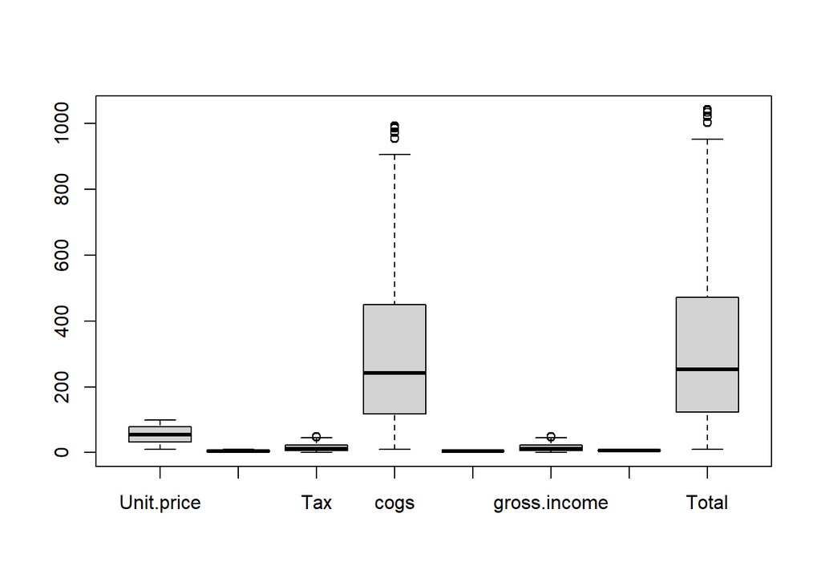

```
##  [1]   47.790   49.490   49.650   47.720   48.605   49.260   48.750   48.685
##  [9]   48.690  955.800  989.800  993.000  954.400  972.100  985.200  975.000
## [17]  973.700  973.800   47.790   49.490   49.650   47.720   48.605   49.260
## [25]   48.750   48.685   48.690 1003.590 1039.290 1042.650 1002.120 1020.705
## [33] 1034.460 1023.750 1022.385 1022.490
```

```r
boxplot(df_sales_numeric)$out
```

Observation: There are outliers in the numerical variables of the datset i.e Tax,cogs,gross income, and Total. They were not dropped.

### IMPLEMENTATION

1.Dimensionality Reduction

```r
df_sales_numeric1 <- df_sales_numeric
head(df_sales_numeric1)
```

```
## # A tibble: 6 x 8
##   Unit.price Quantity   Tax  cogs gross.margin.percen~ gross.income Rating Total
##        <dbl>    <int> <dbl> <dbl>                <dbl>        <dbl>  <dbl> <dbl>
## 1       74.7        7 26.1  523.                  4.76        26.1     9.1 549.
## 2       15.3        5  3.82  76.4                 4.76         3.82    9.6  80.2
## 3       46.3        7 16.2  324.                  4.76        16.2     7.4 341.
## 4       58.2        8 23.3  466.                  4.76        23.3     8.4 489.
## 5       86.3        7 30.2  604.                  4.76        30.2     5.3 634.
## 6       85.4        7 29.9  598.                  4.76        29.9     4.1 628.
```

###### passing numerical data

```r
numeric <- df_sales[,c(6:8,12:16)]
head(numeric)
```

```
## # A tibble: 6 x 8
##   Unit.price Quantity   Tax  cogs gross.margin.percen~ gross.income Rating Total
##        <dbl>    <int> <dbl> <dbl>                <dbl>        <dbl>  <dbl> <dbl>
## 1       74.7        7 26.1  523.                  4.76        26.1     9.1 549.
## 2       15.3        5  3.82  76.4                 4.76         3.82    9.6  80.2
## 3       46.3        7 16.2  324.                  4.76        16.2     7.4 341.
## 4       58.2        8 23.3  466.                  4.76        23.3     8.4 489.
## 5       86.3        7 30.2  604.                  4.76        30.2     5.3 634.
## 6       85.4        7 29.9  598.                  4.76        29.9     4.1 628.
```

###### passing numerical data to prcomp()

```r
sales.pca <- prcomp(df_sales[,c(6,7,8,12,14,15,16)], center =TRUE, scale. = TRUE)
summary(sales.pca)
```

```
## Importance of components:
##                           PC1    PC2    PC3     PC4       PC5       PC6
## Standard deviation     2.2185 1.0002 0.9939 0.30001 1.493e-16 1.104e-16
## Proportion of Variance 0.7031 0.1429 0.1411 0.01286 0.000e+00 0.000e+00
## Cumulative Proportion  0.7031 0.8460 0.9871 1.00000 1.000e+00 1.000e+00
##                              PC7
## Standard deviation     4.052e-17
## Proportion of Variance 0.000e+00
## Cumulative Proportion  1.000e+00
```

### we can plot the principal components for visualization using plot(), and type.

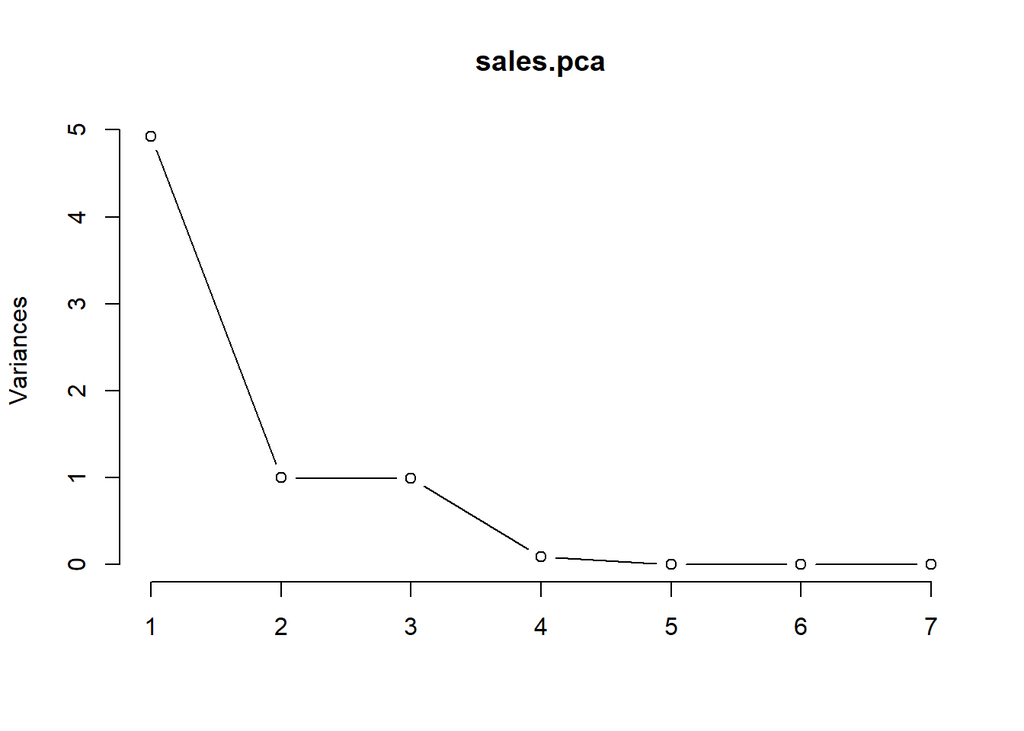

```r
plot(sales.pca,type = 'l')
```

Observation: 7 principal components, each which explain a percentage of the total variation of the Dataset.

### Feature Selection

```r
sales_data1 <- sales_data
head(sales_data1)
```

```
##    Invoice.ID Branch Customer.type Gender           Product.line Unit.price
## 1 750-67-8428      A        Member Female      Health and beauty      74.69
## 2 226-31-3081      C        Normal Female Electronic accessories      15.28
## 3 631-41-3108      A        Normal   Male     Home and lifestyle      46.33
## 4 123-19-1176      A        Member   Male      Health and beauty      58.22
## 5 373-73-7910      A        Normal   Male      Sports and travel      86.31
## 6 699-14-3026      C        Normal   Male Electronic accessories      85.39
##   Quantity     Tax      Date  Time     Payment   cogs gross.margin.percentage
## 1        7 26.1415  1/5/2019 13:08     Ewallet 522.83                4.761905
## 2        5  3.8200  3/8/2019 10:29        Cash  76.40                4.761905
## 3        7 16.2155  3/3/2019 13:23 Credit card 324.31                4.761905
## 4        8 23.2880 1/27/2019 20:33     Ewallet 465.76                4.761905
## 5        7 30.2085  2/8/2019 10:37     Ewallet 604.17                4.761905
## 6        7 29.8865 3/25/2019 18:30     Ewallet 597.73                4.761905
##   gross.income Rating    Total
## 1      26.1415    9.1 548.9715
## 2       3.8200    9.6  80.2200
## 3      16.2155    7.4 340.5255
## 4      23.2880    8.4 489.0480
## 5      30.2085    5.3 634.3785
## 6      29.8865    4.1 627.6165
```

```r
sales_data2 <- sales_data1[,c(6,7,8,12,14,15,16)]
head(sales_data2)
```

```
##   Unit.price Quantity     Tax   cogs gross.income Rating    Total
## 1      74.69        7 26.1415 522.83      26.1415    9.1 548.9715
## 2      15.28        5  3.8200  76.40       3.8200    9.6  80.2200
## 3      46.33        7 16.2155 324.31      16.2155    7.4 340.5255
## 4      58.22        8 23.2880 465.76      23.2880    8.4 489.0480
## 5      86.31        7 30.2085 604.17      30.2085    5.3 634.3785
## 6      85.39        7 29.8865 597.73      29.8865    4.1 627.6165
```

Libraries

```r
library(caret)
library(corrplot)
```

#Calculating the correlation matrix

```r
correlationMatrix <- cor(sales_data2)
# Find attributes that are highly correlated
highlyCorrelated <- findCorrelation(correlationMatrix, cutoff=0.75)
head(highlyCorrelated)
```

```
## [1] 4 7 3
```

```r
head(sales_data2)
```

```
##   Unit.price Quantity     Tax   cogs gross.income Rating    Total
## 1      74.69        7 26.1415 522.83      26.1415    9.1 548.9715
## 2      15.28        5  3.8200  76.40       3.8200    9.6  80.2200
## 3      46.33        7 16.2155 324.31      16.2155    7.4 340.5255
## 4      58.22        8 23.2880 465.76      23.2880    8.4 489.0480
## 5      86.31        7 30.2085 604.17      30.2085    5.3 634.3785
## 6      85.39        7 29.8865 597.73      29.8865    4.1 627.6165
```

```r
# Removing Redundant Features
sales_data3 <-sales_data2[,-c(3,4,7)]
head(sales_data3)
```

```
##   Unit.price Quantity gross.income Rating
## 1      74.69        7      26.1415    9.1
## 2      15.28        5       3.8200    9.6
## 3      46.33        7      16.2155    7.4
## 4      58.22        8      23.2880    8.4
## 5      86.31        7      30.2085    5.3
## 6      85.39        7      29.8865    4.1
```

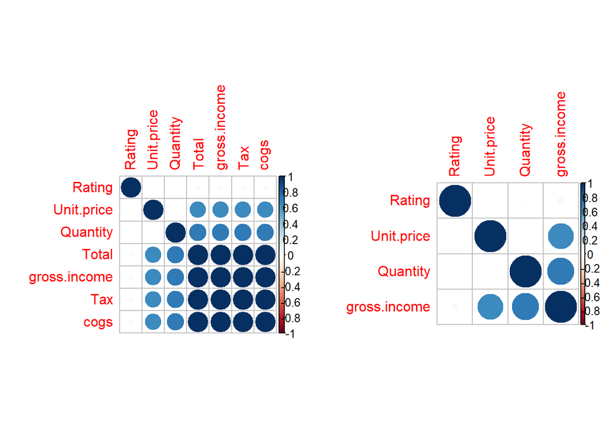

```r
correlationmatrix <- cor(sales_data3)
# Performing our graphical comparison
par(mfrow = c(1, 2))
corrplot(correlationMatrix, order = "hclust")
corrplot(correlationmatrix, order = "hclust")
```

Observation: The key variables are unit price, quantity, gross income and rating.